# Lecture 11: Linear least squares

## Fitting data by polynomials

Here are 5-year averages of the worldwide temperature anomaly as compared to the 1951-1980 average (source: NASA).

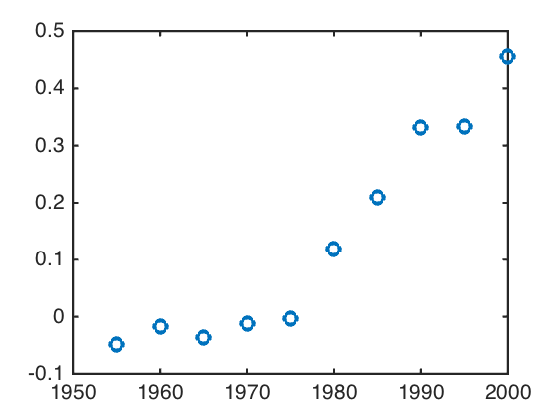

```matlab
year = (1955:5:2000)';
anomaly = [ -0.0480; -0.0180; -0.0360; -0.0120; -0.0040; 0.1180; 0.2100; 0.3320; 0.3340; 0.4560 ];
plot(year,anomaly,'o')
```

The numbers work better if we measure time in years since 1955. (We can quantify that statement later in the course.)

```matlab
t = year-1955;
m = length(t)
```

```
m =

    10
```

A polynomial through all of these points has to have degree at least 9 in general (i.e., unless the points are special). We can solve for the coefficients of this polynomial by solving a $10\times 10$ Vandermonde system.

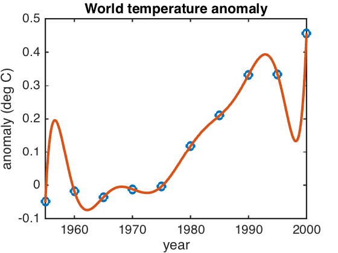

```
[Warning: Matrix is close to singular or badly scaled. Results may be
inaccurate. RCOND =  8.677742e-17.]
[  In pymat_eval (line 31)
  In matlabserver (line 24)]
```

```matlab
A = t.^0;
for j = 1:m-1
    A = [A,t.^j];
end
b = anomaly;

c = A\b;   % coefficients, from degree 0 to m-1

p = @(x) polyval(c(end:-1:1),x-1955);  % interpolating polynomial
plot(year,anomaly,'o')
hold on
fplot(p,[1955 2000])
title('World temperature anomaly')
xlabel('year'), ylabel('anomaly (deg C)')
```

As intended, the polynomial interpolates the data, but it obviously gives a lot of unphysical nonsense. This phenomenon, which is common with interpolating polynomials over equally spaced times, is an example of *overfitting*.

We actually get a better approximation by reducing the degree to 3.

```matlab
A = A(:,1:4);
size(A)
```

```
ans =

    10     4
```

We now have an overdetermined system of linear equations. The easiest way to define a solution is to minimize the 2-norm of the residual--i.e., least squares. In MATLAB we use the same backslash operator as for square systems, even though the algorithms are very different.

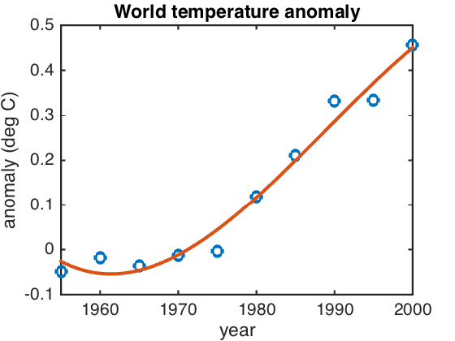

```matlab
c = A\b;   % coefficients, from degree 0 to 3

p = @(x) polyval(c(end:-1:1),x-1955);  % fitting polynomial
plot(year,anomaly,'o')
hold on
fplot(p,[1955 2000])
title('World temperature anomaly')
xlabel('year'), ylabel('anomaly (deg C)')
```

This polynomial certainly describes the data better.

## Three least squares algortithms

There are three distinct ways to solve the general dense linear least squares problem. First, we can pose and solve the normal equations.

```matlab
B = A'*A;  z = A'*b;
size(B)
```

```
ans =

     4     4
```

```matlab
format short e, format compact
[c B\z]
```

```
ans =
  -2.6157e-02  -2.6157e-02
  -9.0823e-03  -9.0823e-03
   7.8573e-04   7.8573e-04
  -7.7483e-06  -7.7483e-06
```

Second, we can use a thin QR factorization to express the range of $A$ orthonormally, and reduce to a triangular square system.

```matlab
[Q,R] = qr(A,0);  z = Q'*b;
[c R\z]
```

```
ans =
  -2.6157e-02  -2.6157e-02
  -9.0823e-03  -9.0823e-03
   7.8573e-04   7.8573e-04
  -7.7483e-06  -7.7483e-06
```

And third, we can use the SVD to orthgonalize both the range and the domain, ultimately getting a diagonal square system.

```matlab
[U,S,V] = svd(A,0);  z = U'*b;
[c V*(z./diag(S))]
```

```
ans =
  -2.6157e-02  -2.6157e-02
  -9.0823e-03  -9.0823e-03
   7.8573e-04   7.8573e-04
  -7.7483e-06  -7.7483e-06
```

In the coming chapters we will take a deep look at why mathematically equivalent algorithms difffer when implemented numerically. It turns out that each of the three algorithms above has a set of problems on which it might be considered the 'best'.